# business sharks lukas and Julien

The correlation spearman per year is 0.0911164 and per month is -0.0642355 , This mean that there is no correlation

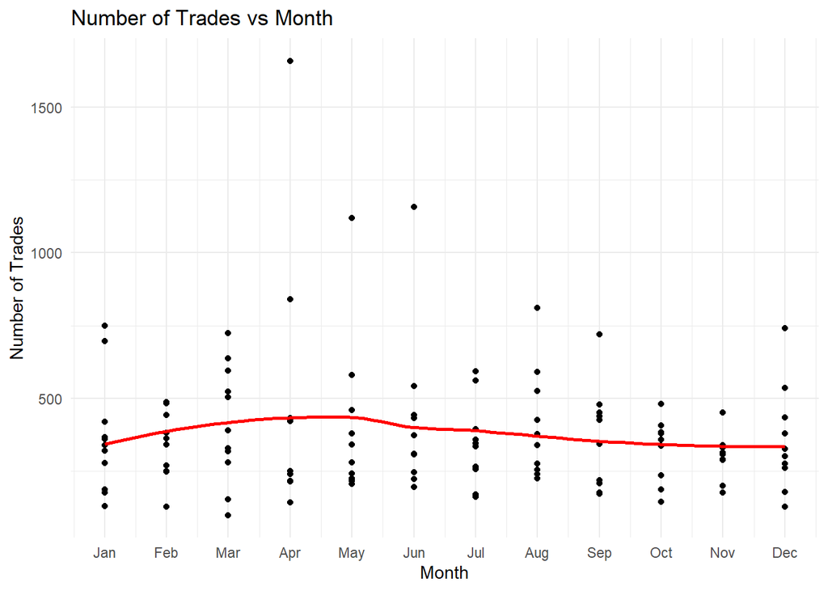

This graph show that this is quite stable and that the number of trade do not depend on the months, We can also compute the same for the trade size.The average trade size is 4.1135234^{4}

3. Chamber, party and excess return

Let Now focus on the Chamber, Party and see if there is any correlation bewteen them.

The correlation between Chamber and excess return is -0.0128372 and betweenParty and excess return is -0.0151868 For Party the result are -0.0354317 and -0.0133452

It mean that the chamber and excess return are not really correlated and we an not say anything between this two party

Let gathering each party and chamber in each state, the result is shown just below

```
## # A tibble: 6 × 4
##   State    Chamber Party Num_Trades
##   <chr>    <chr>   <chr>      <int>
## 1 Alabama  House   R            371
## 2 Alabama  Senate  R            976
## 3 Alaska   Senate  R            118
## 4 Arizona  House   D            358
## 5 Arizona  Senate  R             30
## 6 Arkansas House   R             45
```

Let’s now see some party distribution in each state

```
## # A tibble: 6 × 4
##   State    Chamber Party Num_Trades
##   <chr>    <chr>   <chr>      <int>
## 1 Alabama  House   R            371
## 2 Alabama  Senate  R            976
## 3 Alaska   Senate  R            118
## 4 Arizona  House   D            358
## 5 Arizona  Senate  R             30
## 6 Arkansas House   R             45
```

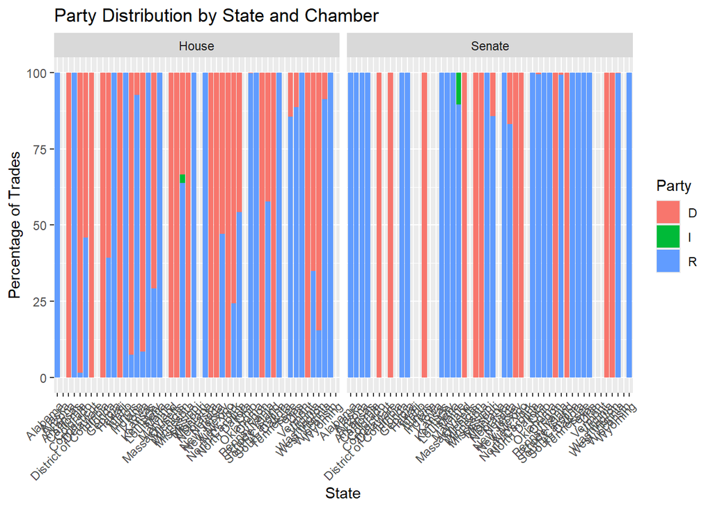

```
## # A tibble: 80 × 4
## # Groups:   State, Chamber [80]
##    State      Chamber Party Num_Trades
##    <chr>      <chr>   <chr>      <int>
##  1 Alabama    House   R            371
##  2 Alabama    Senate  R            976
##  3 Alaska     Senate  R            118
##  4 Arizona    House   D            358
##  5 Arizona    Senate  R             30
##  6 Arkansas   House   R             45
##  7 Arkansas   Senate  R             19
##  8 California House   D           3588
##  9 Colorado   House   D             91
## 10 Colorado   Senate  D             88
## # ℹ 70 more rows
```

```
## # A tibble: 80 × 4
## # Groups:   State, Chamber [80]
##    State                Chamber Party Num_Trades
##    <chr>                <chr>   <chr>      <int>
##  1 Alabama              House   R            371
##  2 Alabama              Senate  R            976
##  3 Alaska               Senate  R            118
##  4 Arizona              House   D            358
##  5 Arizona              Senate  R             30
##  6 Arkansas             House   R             45
##  7 Arkansas             Senate  R             19
##  8 California           House   D           3588
##  9 Colorado             House   D             91
## 10 Colorado             Senate  D             88
## 11 Connecticut          House   D            147
```

[output cut: 69 more lines]

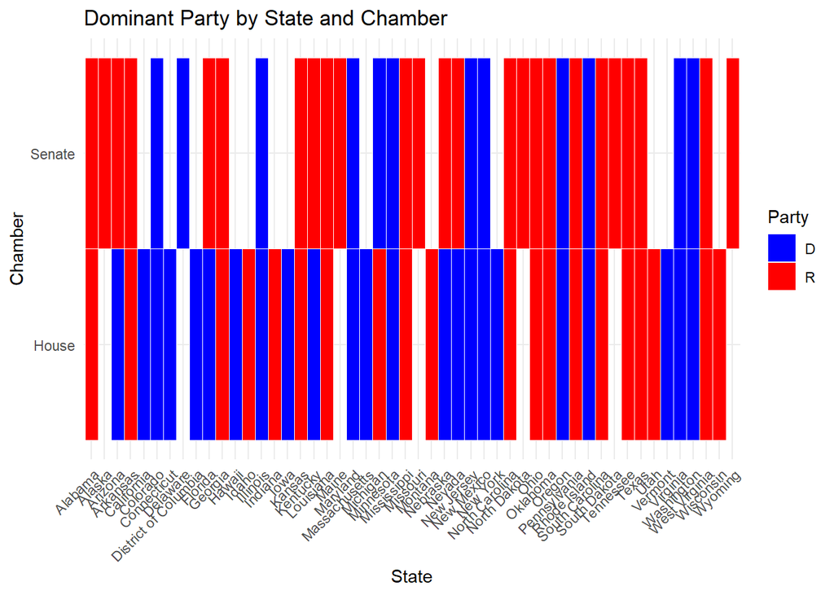